# Union City School District — NJ School Data Almanac – NJ District Profiles

NJ School Data Almanac

Union City School District

HUDSON COUNTY · TRADITIONAL PUBLIC DISTRICT · DFG A · 12,006 STUDENTS (2026)

12,006

Students

89.9%

4-yr grad rate

56.8%

Gr 3-8 ELA

16%

Chronically absent

$20,957

Per pupil

*10 things the data says about Union City School District. Every figure is computed from New Jersey Department of Education data via the njschooldata package — nothing is estimated. Comparisons use District Factor Group (DFG) peers (39 districts in DFG A).*

No. 1 ACHIEVEMENT

## Union City’s Grades 3-8 Reading Scores Didn’t Just Recover From COVID — They Beat Their Pre-Pandemic Mark by 2023

Elementary and middle-school ELA proficiency fell only 3.4 points during the pandemic and climbed to 59.3% by 2023, surpassing the 56.6% it posted before schools closed.

Across New Jersey, the pandemic carved deep holes in elementary and middle-school reading scores that most districts are still trying to climb out of. Union City’s grades 3-8 ELA results tell a different story. Proficiency stood at 56.6% in 2019, slipped to 53.2% in 2022 (a loss of just 3.4 percentage points), and then rebounded to 59.3% in 2023 — higher than where it started.

That 2023 figure is the highest reading proficiency in the district’s testing record, which begins at 49.4% in 2017. Even after settling back to 56.8% in 2024, the district remains at or above its pre-COVID level, a recovery profile that runs counter to the lingering reading losses documented in many systems serving similar student populations.

For a district where 86.7% of students qualified for subsidized meals in 2026 and nearly two in five are multilingual learners, a full reading recovery is the kind of result that earns the urban-turnaround label. The question the data raises is whether 2023’s 59.3% peak was a high-water mark or a level the district can hold as its English-learner share keeps climbing.

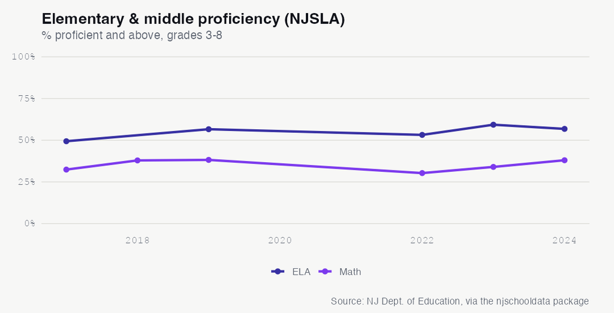

See the underlying data ›

No. 2 EQUITY

## On Union City’s Grades 3-8 Reading Test, Students With Disabilities Pass at 13.8% — One-Fifth the Rate of Their Asian Peers

The 2024 NJSLA shows ELA proficiency ranging from 79.1% for Asian students down to 13.8% for students with disabilities, a 65-point spread inside the same district.

Union City’s overall reading recovery masks a chasm beneath the surface. On the 2024 grades 3-8 NJSLA, proficiency ranged from 79.1% among Asian students and 73.5% among white students down to 13.8% for students with disabilities — a gap of more than 65 percentage points within one district. Students currently classified as English learners proficient at 15.8%, only slightly above.

The district’s largest groups land in the middle. Hispanic students, who make up roughly 95% of enrollment, were proficient at 56.0%, just below the 56.8% total. Students who are economically disadvantaged reached 54.4%. The sharpest divide is not racial but tied to disability status and current language need: students with accommodations passed at 28.2%, and current multilingual learners at 27.4%.

The contrast with former English learners is telling — students who exited EL status passed at 65.5%, above the district average, suggesting the program eventually lifts students once they transition. The open question is how to close the gap for the roughly one in seven students with disabilities still proficient in single-digit-to-teens territory while peers clear 70%.

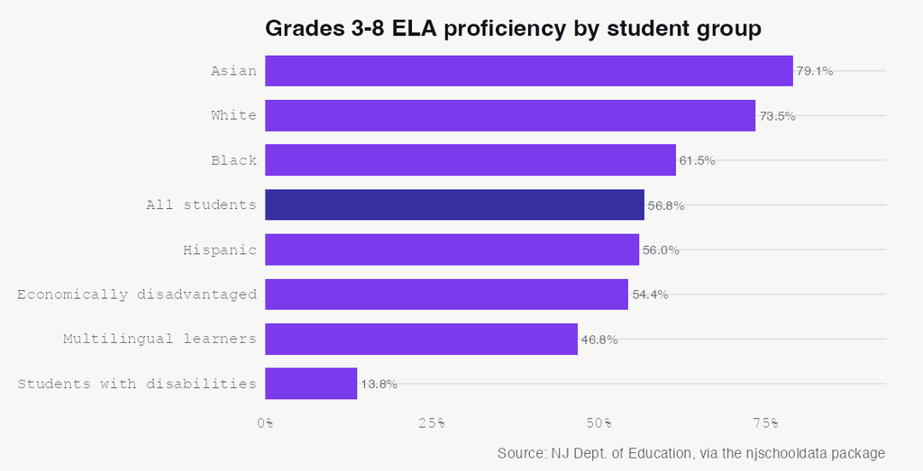

See the underlying data ›

No. 3 ENROLLMENT

## Union City Lost 611 Students in One Year — Its Steepest Enrollment Drop on Record

Enrollment fell 4.8% to 12,006 in 2026, the largest single-year decline in the district’s 12-year file and a sharp break from a decade of growth.

A drop this size in a single year usually reflects more than birth-rate drift, pointing toward kindergarten-entry shifts, family relocation, or movement toward charter and choice options. With per-pupil spending already among the higher tiers in its peer group, whether 2026 marks a one-time correction or the start of sustained contraction will drive the district’s staffing and budget math for years.

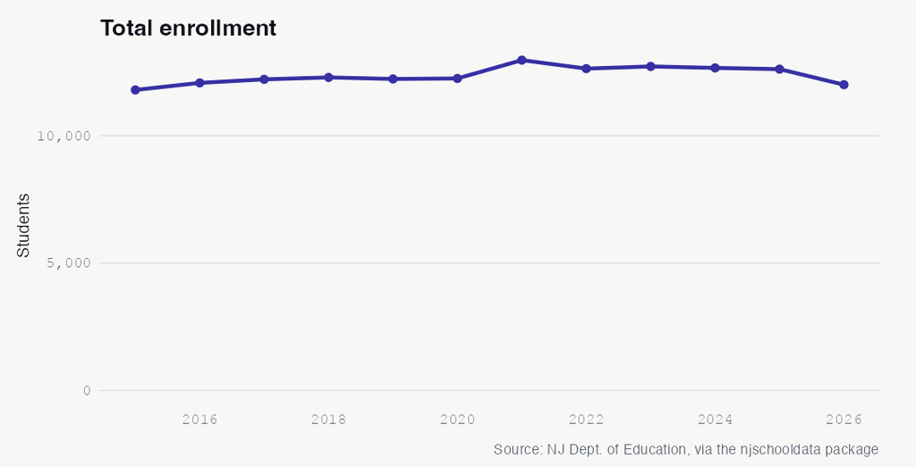

See the underlying data ›

No. 4 ACHIEVEMENT

## Union City’s Grades 3-8 Math Took a Harder COVID Hit Than Reading — Down 7.9 Points — but Clawed Back to Pre-Pandemic Levels by 2024

Math proficiency for grades 3-8 fell from 38.2% in 2019 to 30.3% in 2022, then recovered to 38.0% by 2024 as reading and math diverged in their pandemic paths.

Reading and math did not move together through the pandemic in Union City’s elementary and middle grades. While grades 3-8 reading dipped only 3.4 points, math fell much harder — from 38.2% proficient in 2019 to 30.3% in 2022, a drop of 7.9 percentage points.

The recovery was slower too. Math climbed back to 34.0% in 2023 and reached 38.0% in 2024, essentially returning to its 2019 mark but without the surplus reading achieved. Across the full record, math has trailed reading throughout: 32.4% versus 49.4% in 2017, and 38.0% versus 56.8% in 2024.

The pattern matches a national signature in which pandemic math losses ran deeper and proved stickier than reading losses. Union City has at least restored its pre-COVID math baseline, but the question for the board is whether the district can finally push math proficiency past the high-30s ceiling it has bumped against for nearly a decade.

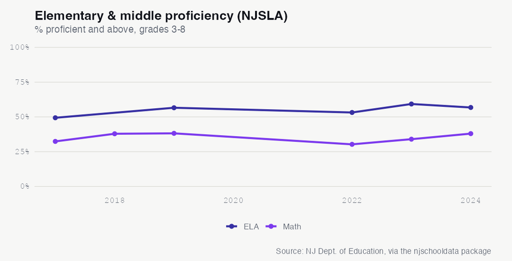

See the underlying data ›

No. 5 ATTENDANCE

## Union City’s Chronic Absenteeism Sits at 16% — A Third Lower Than the 24% Median for Its Peer Group

After spiking to 28% in 2022, the district’s chronic absenteeism fell to 16.0% in 2024, well below the DFG A peer median of 24.1%.

Chronic absenteeism — the share of students missing at least 10% of school days — became one of the defining measures of pandemic disruption. Union City’s rate climbed from 11.7% in 2019 to 28% in 2022, then fell to 21.4% in 2023 and 16.0% in 2024.

The sharper comparison is against peers. The median chronic absenteeism rate among the 39 districts in District Factor Group A was 24.1%. Union City’s 16.0% is roughly a third lower, a notable margin for a district facing the same economic pressures as the rest of its group.

Still, 2024’s 16.0% remains above the district’s pre-pandemic 11.7%, leaving about four percentage points of attendance ground unrecovered. Whether the downward trend continues toward 2019 levels or stalls at 16% will shape how reliably students are in the seats where the district’s achievement gains are made.

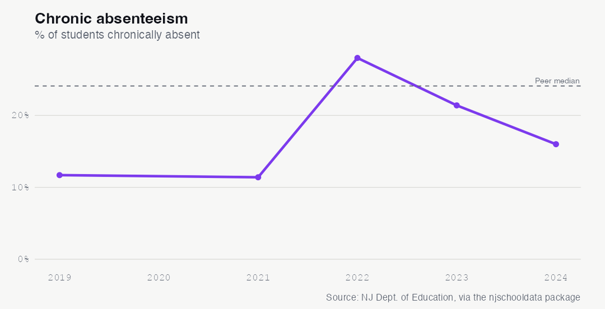

See the underlying data ›

No. 6 DEMOGRAPHICS

## Multilingual Learners Now Make Up 39% of Union City — Up From 24.5% a Decade Ago

The share of students classified as English learners rose from 24.5% in 2015 to 39.1% in 2026, adding more than 1,800 students to the multilingual count.

While Union City’s racial composition barely moved over the past decade — holding near 95% Hispanic — the linguistic profile of its classrooms changed dramatically. Students classified as limited English proficient grew from 2,887 (24.5%) in 2015 to 4,694 (39.1%) in 2026, a rise of nearly 15 percentage points.

The climb was steady, then steep: the LEP share crossed 28% in 2020, 31% in 2021, and 35.6% by 2024 before peaking at 39.4% in 2025. In raw counts, the multilingual-learner population grew by more than 1,800 students even as total enrollment stayed roughly flat.

That shift carries directly into outcomes. Current multilingual learners were proficient at just 27.4% on the 2024 grades 3-8 ELA test, while students who exited EL status reached 65.5%. As nearly two in five students now arrive needing language support, the question is whether instructional staffing — at a 15-to-1 student-teacher ratio — keeps pace with a classroom that looks very different from 2015’s.

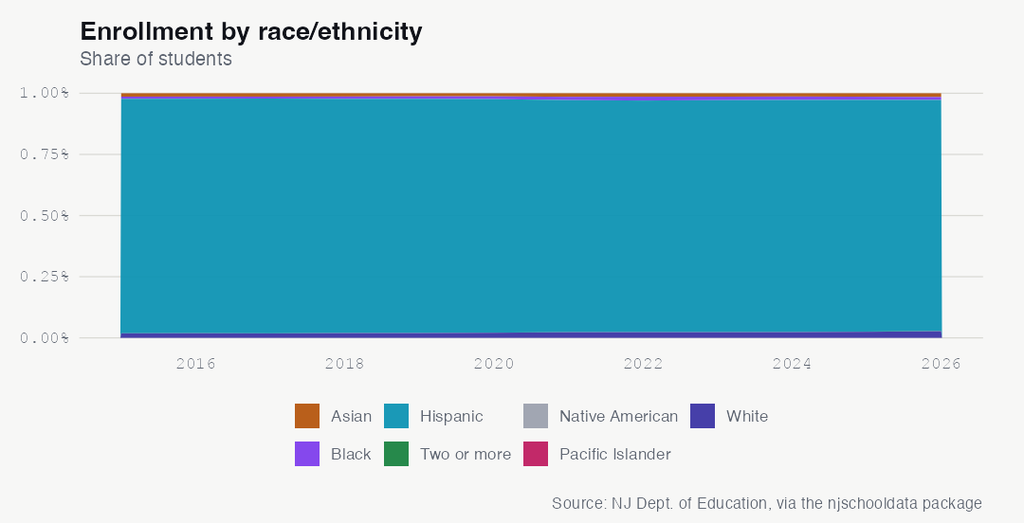

See the underlying data ›

No. 7 FINANCE

## Union City’s Per-Pupil Spending Rose 40% Since 2014 to $20,957, While Daily Enrollment Held Flat

Per-pupil spending reached $20,957 in 2024, above the DFG A peer median of $19,338 and 40.4% higher than 2014, even as average daily enrollment barely changed.

Union City spent $20,957 per pupil in 2024, up 40.4% from $14,925 in 2014 and above the DFG A peer median of $19,338, placing it at the 75th percentile. The climb was steady, crossing $17,000 in 2019 and $20,000 by 2024.

The complicating figure is average daily enrollment, which sat at 11,641 in 2024 — essentially unchanged from 11,446 a decade earlier. Spending rose 40% while the daily count of students it served moved less than 2%, meaning the increase reflects rising costs per student, not a growing student body.

Of 2025 spending, 49.2% went to classroom instruction, with 19.8% to support services and 18.5% to plant operations. With the 2026 enrollment drop of 611 students now on the books, the question is whether per-pupil spending climbs further as fixed costs spread across fewer children.

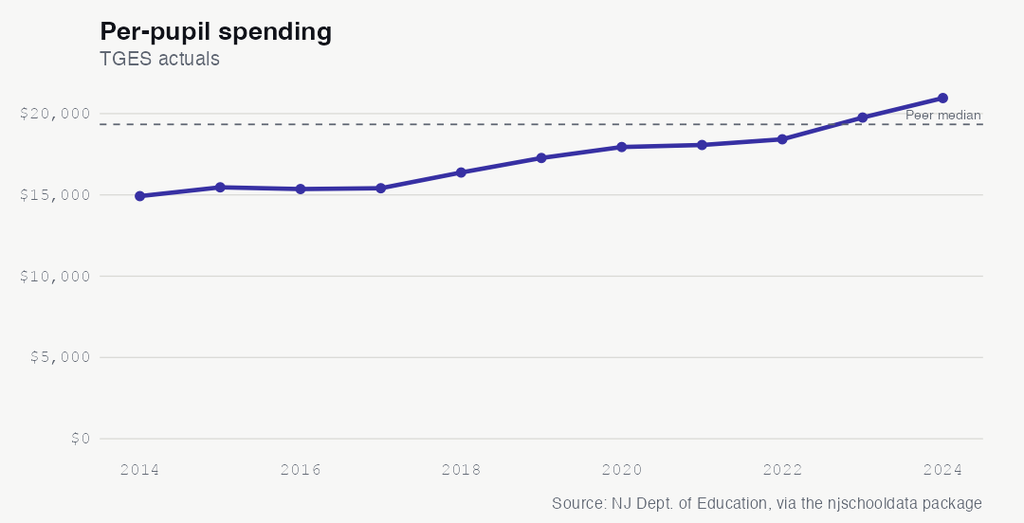

See the underlying data ›

No. 8 GRADUATION

## Union City’s 4-Year Graduation Rate Hit 89.9%, Nearly Five Points Above Its High-Need Peer Median

The 2025 graduation rate of 89.9% sat in the 77th percentile among 39 DFG A peers (median 85.0%), even as the senior cohort grew to 1,068 students.

Union City graduated 89.9% of its 2025 four-year cohort, placing it in the 77th percentile among the 39 districts in its District Factor Group, whose median was 85.0%. The rate has held in a high band for years: 88% in 2020, peaking at 92.1% in 2023 before settling to 90.8% in 2024 and 89.9% in 2025.

What makes 2025 notable is the size of the class behind it. The graduating cohort grew to 1,068 students, up from 923 the year before, so the rate held nearly steady despite a much larger group crossing the stage.

The district’s largest subgroups track the total closely: students who are economically disadvantaged graduated at 90.0% (a cohort of 1,066), and Hispanic students, the overwhelming majority of enrollment, also reached 90.0% (1,016 students). The question for the board is whether the rate can climb back toward its 2023 high or whether the low-90s is a ceiling for now.

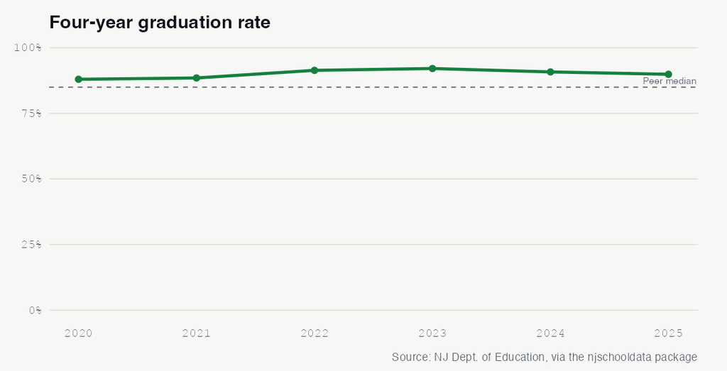

See the underlying data ›

No. 9 EQUITY

The 2025 graduation rate ranged from 95.7% for Black students down to 82.4% for students with disabilities and 81.3% for students experiencing homelessness.

Union City’s strong overall graduation rate spreads unevenly across its student groups. In 2025, students with disabilities graduated at 82.4% from a cohort of 108 — the same group that posts the district’s lowest reading proficiency — while Black students reached 95.7% and female students 93.3%.

The lowest rate of all belonged to students experiencing homelessness, at 81.3% from a small cohort of 16. Multilingual learners, a fast-growing share of enrollment, graduated at 86.9% from a cohort of 260, below the 89.9% district total. Male students, at 86.6%, trailed their female peers by nearly seven points.

The consistency is what stands out: the same populations that lag on the grades 3-8 reading test — students with disabilities and multilingual learners — also finish high school at lower rates. Whether the district’s gains can be extended to these groups is the equity question its data keeps surfacing across grade bands.

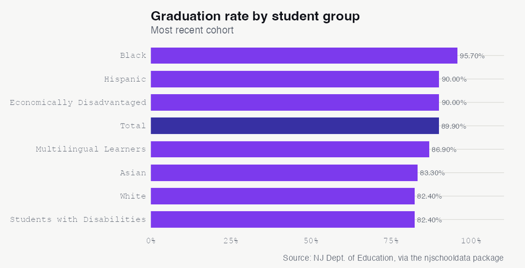

See the underlying data ›

No. 10 COLLEGE READINESS

## In a High-Poverty District, 36.5% of Union City Students Cleared an AP or IB Exam in 2024 — Up From 6.6% in 2018

The share of students scoring 3+ on AP or 4+ on IB rose from 6.6% in 2018 to 36.5% in 2024, climbing well past the state’s 23.0%.

Advanced coursework results in District Factor Group A, the state’s most economically pressed tier, tend to run low. Union City’s do not. In 2024, 36.5% of its students earned a qualifying score of 3 or higher on an AP exam or 4 or higher on IB, against 23.0% statewide.

That result caps a steep climb. In 2018, just 6.6% reached the same bar, far below the state’s 20.5%. The share roughly tripled to 16.9% by 2021, reached 28.1% in 2023, then jumped to 36.5% in 2024. Exam participation rose alongside it, with AP/IB exam-taking reaching 43.1% of students in 2024, up from 8.7% in 2018.

Landing this growth in the same years its grades 3-8 reading scores recovered above pre-COVID levels, the district shows acceleration at both ends of the K-12 pipeline. The forward question is durability: can a 36.5% qualifying rate hold as enrollment contracts and the multilingual-learner share keeps rising?

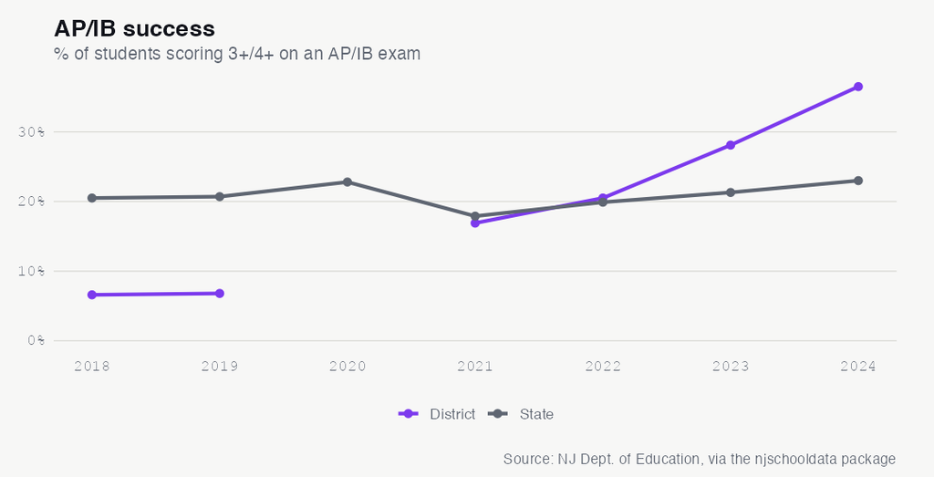

See the underlying data ›

## The Almanac

The full longitudinal record behind the stories above. Every number a reader can check.

### Enrollment (total)

| year | students | yoy | yoy_pct |
| --- | --- | --- | --- |
| 2015 | 11800 | NA | NA |
| 2016 | 12077 | 277 | 2.3 |
| 2017 | 12216 | 139 | 1.2 |
| 2018 | 12291 | 75 | 0.6 |
| 2019 | 12231 | -60 | -0.5 |
| 2020 | 12251 | 20 | 0.2 |
| 2021 | 12970 | 719 | 5.9 |
| 2022 | 12638 | -332 | -2.6 |
| 2023 | 12723 | 85 | 0.7 |
| 2024 | 12665 | -58 | -0.5 |
| 2025 | 12617 | -48 | -0.4 |
| 2026 | 12006 | -611 | -4.8 |

### Demographic share (%) by year

| end_year | white | black | hispanic | asian | native_american | pacific_islander | multiracial |
| --- | --- | --- | --- | --- | --- | --- | --- |
| 2015 | 1.8 | 0.9 | 95.9 | 1.4 | 0 | 0 | 0 |
| 2016 | 1.9 | 0.9 | 95.9 | 1.3 | 0 | 0 | 0 |
| 2017 | 1.8 | 0.8 | 96 | 1.4 | 0 | 0 | 0 |
| 2018 | 1.9 | 1 | 95.7 | 1.3 | 0 | 0 | 0 |
| 2019 | 2 | 1 | 95.7 | 1.3 | 0 | 0 | 0 |
| 2020 | 2.1 | 1.1 | 95.5 | 1.3 | 0 | 0 | 0 |
| 2021 | 2.3 | 1.3 | 94.9 | 1.4 | 0 | 0 | 0 |
| 2022 | 2.3 | 1.6 | 94.7 | 1.4 | 0 | 0 | 0 |
| 2023 | 2.3 | 1.4 | 94.8 | 1.4 | 0 | 0 | 0 |
| 2024 | 2.3 | 1.4 | 94.9 | 1.3 | 0 | 0 | 0 |
| 2025 | 2.5 | 1.3 | 94.7 | 1.4 | 0 | 0 | 0.1 |
| 2026 | 2.7 | 1.2 | 94.5 | 1.5 | 0 | 0 | 0.1 |

### Special populations (LEP, FRL)

| end_year | subgroup | students | pct |
| --- | --- | --- | --- |
| 2015 | lep | 2887 | 24.5 |
| 2015 | free_reduced_lunch | 10877 | 92.2 |
| 2016 | lep | 2917 | 24.2 |
| 2016 | free_reduced_lunch | 10832 | 89.7 |
| 2017 | lep | 2842 | 23.3 |
| 2017 | free_reduced_lunch | 10751 | 88.0 |
| 2018 | lep | 3215 | 26.2 |
| 2018 | free_reduced_lunch | 10888 | 88.6 |
| 2019 | lep | 3355 | 27.4 |
| 2019 | free_reduced_lunch | 10846 | 88.7 |
| 2020 | lep | 3467 | 28.3 |
| 2020 | free_reduced_lunch | 10389 | 84.8 |
| 2021 | lep | 4034 | 31.1 |
| 2021 | free_reduced_lunch | 7730 | 59.6 |
| 2022 | lep | 4006 | 31.7 |
| 2022 | free_reduced_lunch | 10515 | 83.2 |
| 2023 | lep | 4262 | 33.5 |
| 2023 | free_reduced_lunch | 10751 | 84.5 |
| 2024 | lep | 4509 | 35.6 |
| 2024 | free_reduced_lunch | 10423 | 82.3 |
| 2025 | lep | 4971 | 39.4 |
| 2025 | free_reduced_lunch | 10005 | 79.3 |
| 2026 | lep | 4694 | 39.1 |
| 2026 | free_reduced_lunch | 10409 | 86.7 |

### Graduation rate 4yr (total)

| year | grad_rate | cohort |
| --- | --- | --- |
| 2020 | 88 | 966 |
| 2021 | 88.5 | 906 |
| 2022 | 91.4 | 945 |
| 2023 | 92.1 | 928 |
| 2024 | 90.8 | 923 |
| 2025 | 89.9 | 1068 |

### Graduation by subgroup (2025)

| subgroup | grad_rate | cohort |
| --- | --- | --- |
| black | 95.7 | 23 |
| female | 93.3 | 524 |
| economically disadvantaged | 90.0 | 1066 |
| hispanic | 90.0 | 1016 |
| military-connected students | 90.0 | 10 |
| total | 89.9 | 1068 |
| multilingual learners | 86.9 | 260 |
| male | 86.6 | 544 |
| asian | 83.3 | 12 |
| students with disabilities | 82.4 | 108 |
| white | 82.4 | 17 |
| students experiencing homelessness | 81.3 | 16 |
| american indian | NA | NA |
| migrant students | NA | NA |
| non-binary/undesignated gender | NA | NA |
| students in foster care | NA | NA |
| multiracial | NA | NA |

### NJGPA high-school proficiency (% proficient+)

| year | test | prof_above | valid |
| --- | --- | --- | --- |
| 2023 | ela | 73.0 | 827 |
| 2023 | math | 34.0 | 848 |
| 2024 | ela | 72.9 | 951 |
| 2024 | math | 32.2 | 951 |
| 2025 | ela | 70.8 | 887 |
| 2025 | math | 38.8 | 887 |

### NJGPA ELA by subgroup (2025)

[output not shown]

### NJSLA grades 3-8 proficiency (% proficient+, enrollment-weighted across grades)

| testing_year | test_name | prof |
| --- | --- | --- |
| 2017 | ela | 49.4 |
| 2017 | math | 32.4 |
| 2018 | math | 37.9 |
| 2019 | ela | 56.6 |
| 2019 | math | 38.2 |
| 2022 | ela | 53.2 |
| 2022 | math | 30.3 |
| 2023 | ela | 59.3 |
| 2023 | math | 34.0 |
| 2024 | ela | 56.8 |
| 2024 | math | 38.0 |

### NJSLA ELA proficiency by subgroup (2024, grades 3-8)

| subgroup | prof |
| --- | --- |
| asian | 79.1 |
| white | 73.5 |
| non_ed | 71.9 |
| FORMER - ML | 69.1 |
| lep_former | 65.5 |
| black | 61.5 |
| female | 60.9 |
| total_population | 56.8 |
| hispanic | 56.0 |
| ed | 54.4 |
| male | 52.8 |
| lep_current_former | 49.2 |
| MULTILINGUAL LEARNERS | 46.8 |
| sped_accomodations | 28.2 |
| CURRENT - ML | 27.4 |
| lep_current | 15.8 |
| special_education | 13.8 |

### Chronic absenteeism (% chronically absent)

| year | chronic_pct |
| --- | --- |
| 2019 | 11.7 |
| 2021 | 11.4 |
| 2022 | 28 |
| 2023 | 21.4 |
| 2024 | 16 |

### Disciplinary removals

[output not shown]

### Police notifications (incident counts)

| year | violence | weapons | vandalism | substances | hib | other |
| --- | --- | --- | --- | --- | --- | --- |
| 2019 | 32 | 8 | 8 | 5 | 0 | 2 |
| 2020 | 6 | 3 | 3 | 4 | 0 | 0 |
| 2021 | NA | NA | NA | NA | NA | NA |
| 2022 | 5 | 4 | 4 | 0 | 0 | 0 |
| 2023 | 3 | 6 | 0 | 0 | 0 | 0 |
| 2024 | 0 | 2 | 0 | 0 | 1 | 0 |

### HIB (harassment/intimidation/bullying) investigations

| end_year | alleged | confirmed |
| --- | --- | --- |
| 2019 | 2 | 22 |
| 2020 | 3 | 17 |
| 2021 | 0 | 0 |
| 2022 | 0 | 6 |
| 2023 | 0 | 31 |
| 2024 | 0 | 20 |

### SAT participation (% of grade)

| year | sat_part | state_sat |
| --- | --- | --- |
| 2018 | 96.6 | 72.2 |
| 2019 | 86 | 72.1 |
| 2020 | 0 | 71.1 |
| 2021 | 88.2 | 45.4 |
| 2022 | 99.4 | 60.8 |
| 2023 | 100 | 61.9 |
| 2024 | 100 | 62.7 |

### AP/IB & dual enrollment (% of students)

| year | apib_coursework | apib_exam | ap3_ib4 | state_ap3_ib4 | dual |
| --- | --- | --- | --- | --- | --- |
| 2018 | 9.4 | 8.7 | 6.6 | 20.5 | 0 |
| 2019 | 9.6 | 9 | 6.8 | 20.7 | 10.2 |
| 2020 | 50.2 | 0 | NA | 22.8 | 19.8 |
| 2021 | 35.5 | 26.2 | 16.9 | 17.9 | 16.6 |
| 2022 | 32.1 | 31.6 | 20.5 | 19.9 | 22.5 |
| 2023 | 34.2 | 34.2 | 28.1 | 21.3 | 30.3 |
| 2024 | 42.4 | 43.1 | 36.5 | 23 | 19.4 |

### Special education (raw rows; inspect for classification rate)

| end_year | district_id |
| --- | --- |
| 2024 | 5240 |

### Per-pupil spending (TGES actuals)

| year | per_pupil | rank | ade |
| --- | --- | --- | --- |
| 2014 | 14925 | 68 | 11446 |
| 2015 | 15466 | 75 | 11762 |
| 2016 | 15360 | 66 | 12070 |
| 2017 | 15410 | 60 | 12348 |
| 2018 | 16377 | 75 | 12244 |
| 2019 | 17271 | 79 | 12198 |
| 2020 | 17945 | 80 | 12210 |
| 2021 | 18070 | 74 | 11796 |
| 2022 | 18421 | 69 | 11630 |
| 2023 | 19758 | 77 | 11623 |
| 2024 | 20957 | 78 | 11641 |

### Spending composition shares (2025)

| classroom_share | support_services_share | administration_share | plant_ops_share | food_service_share | extracurricular_share | equipment_share |
| --- | --- | --- | --- | --- | --- | --- |
| 49.2 | 19.8 | 8.2 | 18.5 | NA | 0.5 | 0 |

### Staffing ratios

| end_year | student_teacher_district | student_admin_district | student_counselor_district | student_nurse_district |
| --- | --- | --- | --- | --- |
| 2024 | 15:1 | 145:1 | 515:1 | 715:1 |

Back to top